# MScA, Linear and Nonlinear Models (31010) Week 7, Workshop 2 Multinomial Regression Models

Yuri Balasanov, © iLykei 2016

```r
library(faraway)
library(MASS)
library(nnet)
```

# 1 Multinomial regression with simulated data

First, use simulated data to see differences between models.

Load the data from book:  
John K. Kruschke, Doing Bayesian Data Analysis, A Tutorial with R, JAGS, and STAN, 2015, Elsevier  
Data are available on the [author’s web site](https://sites.google.com/site/doingbayesiandataanalysis/software-installation). This example is also used to illustrate multinomial regression in Bayesian framework in the course Bayesian Methods.

```r
myData = read.csv( file=paste(dataPath,"CondLogistRegData1.csv",sep="/"))
head(myData)
```

```
##            X1         X2 Y
## 1 -0.08714736 -1.0813422 2
## 2 -0.72256565 -1.5838631 1
## 3  0.17918961  0.9717904 3
## 4 -1.15975176  0.5026244 1
## 5 -0.72711762  1.3757045 3
## 6  0.53341559  1.7746506 3
```

```r
table(myData$Y)
```

```
##
##   1   2   3   4
## 122 142 150  61
```

```r
myData$Yfa<-as.factor(myData$Y)
```

Data contain 4 classes and 2 numeric predictor variables.  
New variable `Yfa` is a factor version of `Y`.

Plot the data coding different classes with colors:

- Class 1 is orange
- Class 2 is magenta
- Class 3 is blue
- Class 4 is black

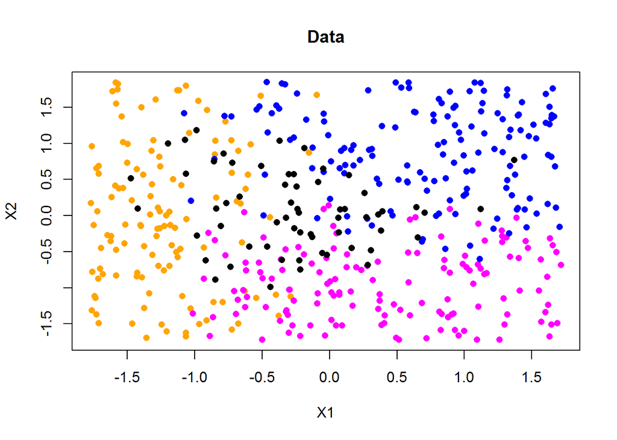

```r
plot(myData$X1,myData$X2,pch=16,col="orange",main="Data",xlab="X1",ylab="X2")
points(myData$X1[myData$Y==2],myData$X2[myData$Y==2],col="magenta",pch=16)
points(myData$X1[myData$Y==3],myData$X2[myData$Y==3],col="blue",pch=16)
points(myData$X1[myData$Y==4],myData$X2[myData$Y==4],col="black",pch=16)
```

## 1.1 Proportional odds model

### 1.1.1 Logit link

Let $p_j(x_i)=P(Y_i \le j|x_i)$. Then proportional odds regression based on logit link is

$$\ln \left( \frac{p_j(x_i)}{1-p_j(x_i)} \right)=\eta_{j,i}=\theta_j-\beta_1 x_{i,1}-\ldots-\beta_k x_{i,k},~~j=1,\ldots,J-1,$$
where $J$ is the number of ordered categories.

Probit and complimentary log log links can also be used.

The model equations show that all slopes are the same, meaning that the lines separating ordered classes are the same, class separating hyperplanes differ only by intercepts.

Proportional odds models are equivalent to nested binomial models:

1. Class 1 against classes 2, 3, 4;
2. Classes 1, 2 against classes 3, 4;
3. Classes 1, 2, 3 against class 4.

Fit proportional odds model using `polr()` from `MASS`

```r
pom<-polr(Yfa~X1+X2,data=myData)
summary(pom)
```

```
##
## Re-fitting to get Hessian
```

```
## Call:
## polr(formula = Yfa ~ X1 + X2, data = myData)
##
## Coefficients:
##     Value Std. Error t value
## X1 1.0930    0.09997  10.934
## X2 0.5701    0.08736   6.525
##
## Intercepts:
##     Value    Std. Error t value
## 1|2  -1.3356   0.1239   -10.7764
## 2|3   0.5857   0.1123     5.2169
## 3|4   2.6293   0.1638    16.0486
##
## Residual Deviance: 1086.976
## AIC: 1096.976
```

```r
pomPred<-predict(pom)
```

Plot the data and predictions by `pom`.

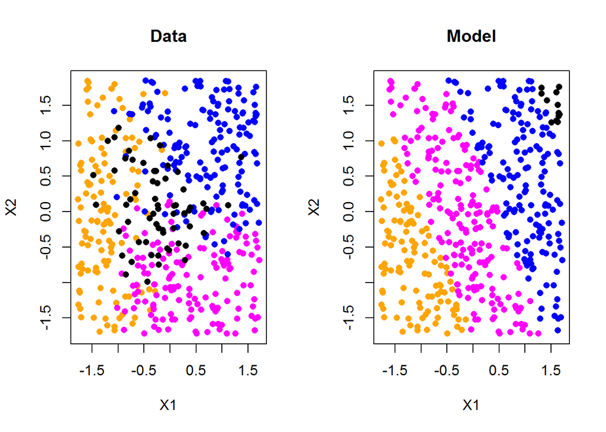

```r
par(mfrow=c(1,2))
plot(myData$X1,myData$X2,pch=16,col="orange",main="Data",xlab="X1",ylab="X2")
points(myData$X1[myData$Y==2],myData$X2[myData$Y==2],col="magenta",pch=16)
points(myData$X1[myData$Y==3],myData$X2[myData$Y==3],col="blue",pch=16)
points(myData$X1[myData$Y==4],myData$X2[myData$Y==4],col="black",pch=16)

plot(myData$X1,myData$X2,pch=16,col="orange",main="Model",xlab="X1",ylab="X2")
points(myData$X1[pomPred==2],myData$X2[pomPred==2],col="magenta",pch=16)
points(myData$X1[pomPred==3],myData$X2[pomPred==3],col="blue",pch=16)
points(myData$X1[pomPred==4],myData$X2[pomPred==4],col="black",pch=16)
```

```r
par(mfrow=c(1,1))
```

### 1.1.2 Probit link

Probit model assumes the same pattern of classes as logit, but uses probit link.

Fit the model using `probit` as method in `polr()`.

```r
pom.probit<-polr(Yfa~X1+X2,data=myData,method="probit")
summary(pom.probit)
```

```
##
## Re-fitting to get Hessian
```

```
## Call:
## polr(formula = Yfa ~ X1 + X2, data = myData, method = "probit")
##
## Coefficients:
##     Value Std. Error t value
## X1 0.6037    0.05587  10.805
## X2 0.3089    0.05210   5.928
##
## Intercepts:
##     Value    Std. Error t value
## 1|2  -0.8214   0.0725   -11.3244
## 2|3   0.2739   0.0649     4.2212
## 3|4   1.3654   0.0774    17.6454
##
## Residual Deviance: 1112.903
## AIC: 1122.903
```

```r
pomPred.probit<-predict(pom.probit)
```

Plot the data and predictions by the model.

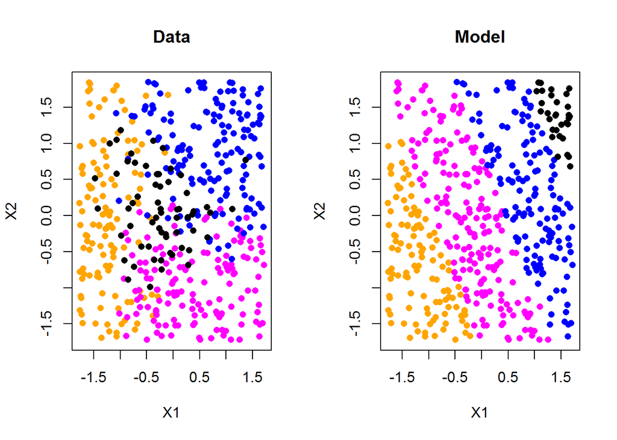

```r
par(mfrow=c(1,2))
plot(myData$X1,myData$X2,pch=16,col="orange",main="Data",xlab="X1",ylab="X2")
points(myData$X1[myData$Y==2],myData$X2[myData$Y==2],col="magenta",pch=16)
points(myData$X1[myData$Y==3],myData$X2[myData$Y==3],col="blue",pch=16)
points(myData$X1[myData$Y==4],myData$X2[myData$Y==4],col="black",pch=16)

plot(myData$X1,myData$X2,pch=16,col="orange",main="Model",xlab="X1",ylab="X2")
points(myData$X1[pomPred.probit==2],myData$X2[pomPred.probit==2],col="magenta",pch=16)
points(myData$X1[pomPred.probit==3],myData$X2[pomPred.probit==3],col="blue",pch=16)
points(myData$X1[pomPred.probit==4],myData$X2[pomPred.probit==4],col="black",pch=16)
```

```r
par(mfrow=c(1,1))
```

### 1.1.3 Complimentary log-log link

Complimentary log-log model is based on the same assumption about pattern of classes, but uses complimentary log-log link.

Fit the model using `cloglog` as method in `polr()`.

```r
pom.cloglog<-polr(Yfa~X1+X2,data=myData,method="cloglog")
summary(pom.cloglog)
```

```
##
## Re-fitting to get Hessian
```

```
## Call:
## polr(formula = Yfa ~ X1 + X2, data = myData, method = "cloglog")
##
## Coefficients:
##     Value Std. Error t value
## X1 0.3365    0.06271   5.367
## X2 0.3389    0.05938   5.707
##
## Intercepts:
##     Value    Std. Error t value
## 1|2  -1.2532   0.0935   -13.4006
## 2|3  -0.1195   0.0661    -1.8075
## 3|4   0.8364   0.0582    14.3759
##
## Residual Deviance: 1199.882
## AIC: 1209.882
```

```r
pomPred.cloglog<-predict(pom.cloglog)
```

Plot the data and predictions by the model.

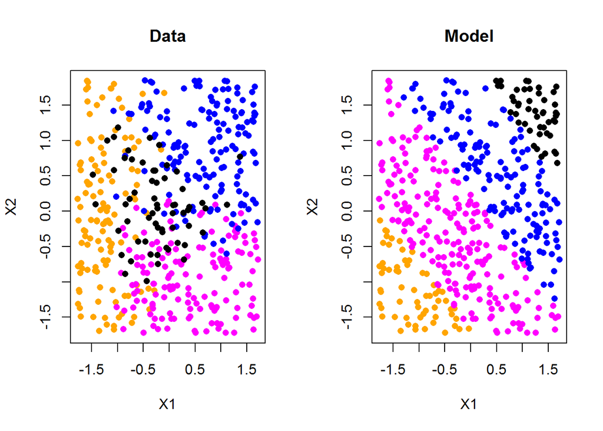

```r
par(mfrow=c(1,2))
plot(myData$X1,myData$X2,pch=16,col="orange",main="Data",xlab="X1",ylab="X2")
points(myData$X1[myData$Y==2],myData$X2[myData$Y==2],col="magenta",pch=16)
points(myData$X1[myData$Y==3],myData$X2[myData$Y==3],col="blue",pch=16)
points(myData$X1[myData$Y==4],myData$X2[myData$Y==4],col="black",pch=16)

plot(myData$X1,myData$X2,pch=16,col="orange",main="Model",xlab="X1",ylab="X2")
points(myData$X1[pomPred.cloglog==2],myData$X2[pomPred.cloglog==2],col="magenta",pch=16)
points(myData$X1[pomPred.cloglog==3],myData$X2[pomPred.cloglog==3],col="blue",pch=16)
points(myData$X1[pomPred.cloglog==4],myData$X2[pomPred.cloglog==4],col="black",pch=16)
```

```r
par(mfrow=c(1,1))
```

## 1.2 Multinomial logit model

All three models in the previous sections showed poor fit because the pattern of classes was not consistent with proportional odds assumption: classes did not form layers on the plot.

Multinomial regression does not make assumption about monotonicity of classes locations.

Instead it defines linear boundaries between all pairs of classes.

The following multinomial regression function `multinom()` from `nnet` trains multinomial logit model using neural networks.

Fit the model.

```r
mmod<-multinom(Yfa~X1+X2,data=myData)
(smry<-summary(mmod))
```

```
## Call:
## multinom(formula = Yfa ~ X1 + X2, data = myData)
##
## Coefficients:
##   (Intercept)       X1         X2
## 2    1.716915 5.941394 -2.6532206
## 3    1.802195 6.778153  2.7068260
## 4    2.552253 4.117051  0.3500351
##
## Std. Errors:
##   (Intercept)        X1        X2
## 2   0.5309957 0.6071153 0.4070341
## 3   0.5285663 0.6387993 0.4211390
## 4   0.4778926 0.5484448 0.2509733
##
## Residual Deviance: 474.5488
## AIC: 492.5488
```

```r
mmodPred<-predict(mmod)
```

Show how the model separates all classes.

Extract coefficients and make a function calculating hyperplane from coefficients.

```r
smry$coefficients
```

```
##   (Intercept)       X1         X2
## 2    1.716915 5.941394 -2.6532206
## 3    1.802195 6.778153  2.7068260
## 4    2.552253 4.117051  0.3500351
```

```r
makeHyperplane<-function(x1,coeffi){
  cbind(x1,-(coeffi[1]+x1*coeffi[2])/coeffi[3])
}
```

Make hyperplanes separating class 1 from classes 2, 3, 4.  
This will use each row of estimated coefficients:

$$\eta_{i,j}=\beta_{0,1|j}+\beta_{1,1|j} X_{i,1}+\beta_{2,1|j} X_{i,2}=\ln \left(\frac{p_{i,j}}{p_{i,1}} \right),~j=2,3,4.$$

Find the hyperplanes satisfying

$$X_2=\frac{\beta_{0,1|j}+\beta_{1,1|j} X_{1}}{-\beta_{2,1|j}}.$$

For hyperplanes separating class 2 from classes 3 and 4 use differences between rows of coefficients.  
For example, hyperplane separating class 2 from class 3 is based on:

$$\eta_{i,2}=\beta_{0,1|2}+\beta_{1,1|2} X_{i,1}+\beta_{2,1|2} X_{i,2}=\ln \left(\frac{p_{i,2}}{p_{i,1}} \right)$$
and
$$\eta_{i,3}=\beta_{0,1|3}+\beta_{1,1|3} X_{i,1}+\beta_{2,1|3} X_{i,2}=\ln \left(\frac{p_{i,3}}{p_{i,1}} \right),$$
from which by differencing find
$$\left[ \beta_{0,1|3}-\beta_{0,1|2} \right]+
\left[ \beta_{1,1|3}-\beta_{1,1|2} \right] X_{i,1}+
\left[ \beta_{2,1|3}-\beta_{2,1|2} \right] X_{i,2}=\ln \left(\frac{p_{i,3}}{p_{i,1}} \right)-\ln \left(\frac{p_{i,2}}{p_{i,1}} \right)=\ln \left(\frac{p_{i,3}}{p_{i,2}} \right)$$

Then the hyperplane satisfies

$$X_2=\frac{\left[ \beta_{0,1|3}-\beta_{0,1|2} \right]+\left[ \beta_{1,1|3}-\beta_{1,1|2} \right] X_{i,1}}{-\left[ \beta_{2,1|3}-\beta_{2,1|2} \right]}.$$

```r
hpplane12<-makeHyperplane(myData$X1,smry$coefficients[1,])
hpplane13<-makeHyperplane(myData$X1,smry$coefficients[2,])
hpplane14<-makeHyperplane(myData$X1,smry$coefficients[3,])
hpplane23<-makeHyperplane(myData$X1,smry$coefficients[2,]-smry$coefficients[1,])
hpplane24<-makeHyperplane(myData$X1,smry$coefficients[3,]-smry$coefficients[1,])
hpplane34<-makeHyperplane(myData$X1,smry$coefficients[3,]-smry$coefficients[2,])
```

This model has different slopes and intercepts for each boundary.

Plot the data and model predictions.

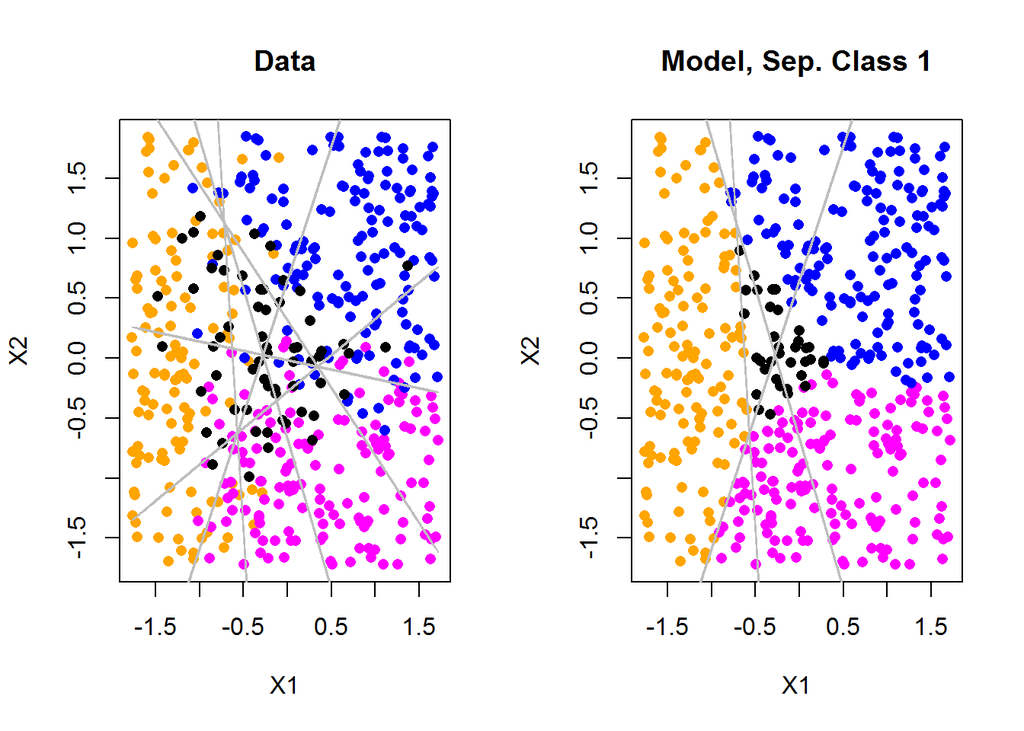

```r
par(mfrow=c(1,2))
plot(myData$X1,myData$X2,pch=16,col="orange",main="Data",xlab="X1",ylab="X2")
points(myData$X1[myData$Y==2],myData$X2[myData$Y==2],col="magenta",pch=16)
points(myData$X1[myData$Y==3],myData$X2[myData$Y==3],col="blue",pch=16)
points(myData$X1[myData$Y==4],myData$X2[myData$Y==4],col="black",pch=16)
lines(hpplane12,col="grey",lty=2,lwd=1)
lines(hpplane13,col="grey",lty=2,lwd=1)
lines(hpplane14,col="grey",lty=2,lwd=1)
lines(hpplane23,col="grey",lty=2,lwd=1)
lines(hpplane24,col="grey",lty=2,lwd=1)
lines(hpplane34,col="grey",lty=2,lwd=1)

# Separate class 1 from classes 2,3,4
plot(myData$X1,myData$X2,pch=16,col="orange",main="Model, Sep. Class 1",xlab="X1",ylab="X2")
points(myData$X1[mmodPred==2],myData$X2[mmodPred==2],col="magenta",pch=16)
points(myData$X1[mmodPred==3],myData$X2[mmodPred==3],col="blue",pch=16)
points(myData$X1[mmodPred==4],myData$X2[mmodPred==4],col="black",pch=16)
lines(hpplane12,col="grey",lty=2,lwd=1)
lines(hpplane13,col="grey",lty=2,lwd=1)
lines(hpplane14,col="grey",lty=2,lwd=1)
```

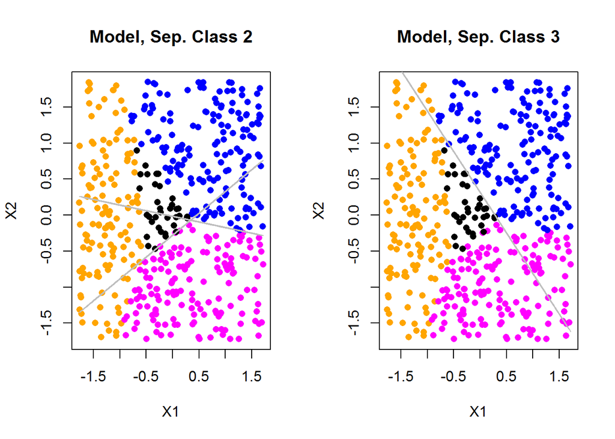

```r
# Separate class 2 from classes 3,4
plot(myData$X1,myData$X2,pch=16,col="orange",main="Model, Sep. Class 2",xlab="X1",ylab="X2")
points(myData$X1[mmodPred==2],myData$X2[mmodPred==2],col="magenta",pch=16)
points(myData$X1[mmodPred==3],myData$X2[mmodPred==3],col="blue",pch=16)
points(myData$X1[mmodPred==4],myData$X2[mmodPred==4],col="black",pch=16)
lines(hpplane23,col="grey",lty=2,lwd=1)
lines(hpplane24,col="grey",lty=2,lwd=1)

# Separate class 3 from class 4
plot(myData$X1,myData$X2,pch=16,col="orange",main="Model, Sep. Class 3",xlab="X1",ylab="X2")
points(myData$X1[mmodPred==2],myData$X2[mmodPred==2],col="magenta",pch=16)
points(myData$X1[mmodPred==3],myData$X2[mmodPred==3],col="blue",pch=16)
points(myData$X1[mmodPred==4],myData$X2[mmodPred==4],col="black",pch=16)
lines(hpplane34,col="grey",lty=2,lwd=1)
```

```r
par(mfrow=c(1,1))
```

Model unconstrained by proportional odds assumption captures the pattern better.

# 2 Election data example

## 2.1 Multinomial regression

The following example is based on data `nes96` from `faraway`.

```r
head(nes96)
```

```
##   popul TVnews selfLR ClinLR DoleLR     PID age  educ   income    vote
## 1     0      7 extCon extLib    Con  strRep  36    HS $3Kminus    Dole
## 2   190      1 sliLib sliLib sliCon weakDem  20  Coll $3Kminus Clinton
## 3    31      7    Lib    Lib    Con weakDem  24 BAdeg $3Kminus Clinton
## 4    83      4 sliLib    Mod sliCon weakDem  28 BAdeg $3Kminus Clinton
## 5   640      7 sliCon    Con    Mod  strDem  68 BAdeg $3Kminus Clinton
## 6   110      3 sliLib    Mod    Con weakDem  21  Coll $3Kminus Clinton
```

Response is party identification `PID` with levels

```r
levels(nes96$PID)
```

```
## [1] "strDem"  "weakDem" "indDem"  "indind"  "indRep"  "weakRep" "strRep"
```

For convenience combine all colors of Democrats in one category “Democrat”. Do the same with Independents and with Republicans.

```r
sPID<-nes96$PID
levels(sPID)<-c("Democrat","Democrat","Independent","Independent","Independent","Republican","Republican")
summary(sPID)
```

```
##    Democrat Independent  Republican
##         380         239         325
```

Transform categorical buckets of income into numeric variable by taking midpoint of each range.

```r
table(nes96$income)
```

```
##
##   $3Kminus    $3K-$5K    $5K-$7K    $7K-$9K   $9K-$10K  $10K-$11K
##         19         12         17         19         18         13
##  $11K-$12K  $12K-$13K  $13K-$14K  $14K-$15K  $15K-$17K  $17K-$20K
##         11         17         10         15         23         35
##  $20K-$22K  $22K-$25K  $25K-$30K  $30K-$35K  $35K-$40K  $40K-$45K
##         26         39         68         70         62         48
##  $45K-$50K  $50K-$60K  $60K-$75K  $75K-$90K $90K-$105K  $105Kplus
##         51        100        103         53         47         68
```

```r
inca<-c(1.5,4,6,8,9.5,10.5,11.5,12.5,13.5,14.5,16,18.5,21,23.5,27.5,32.5,37.5,42.5,47.5,55,67.5,82.5,97.5,115)
nincome<-inca[unclass(nes96$income)]
summary(nincome)
```

```
##    Min. 1st Qu.  Median    Mean 3rd Qu.    Max.
##    1.50   23.50   37.50   46.58   67.50  115.00
```

Other two variables included in the example are levels of education and age.

```r
table(nes96$educ)
```

```
##
##     MS HSdrop     HS   Coll  CCdeg  BAdeg  MAdeg
##     13     52    248    187     90    227    127
```

```r
table(nes96$age)
```

```
##
## 19 20 21 22 23 24 25 26 27 28 29 30 31 32 33 34 35 36 37 38 39 40 41 42 43
##  3  6 13  9  6 16 13 13 16 14 15 22 20 23 24 24 32 26 26 25 23 27 21 23 24
## 44 45 46 47 48 49 50 51 52 53 54 55 56 57 58 59 60 61 62 63 64 65 66 67 68
## 18 20 15 22 20 20 19 15 12 17  8 20 15 15 15  8  4  9 19 10  9  9  6 16 14
## 69 70 71 72 73 74 75 76 77 78 79 80 81 82 83 84 85 87 88 89 91
## 10 14  5  9 11  9  5 13  5  6  7  2  2  4  3  3  5  4  5  1  2
```

Plot party categories in the space of income vs. age.

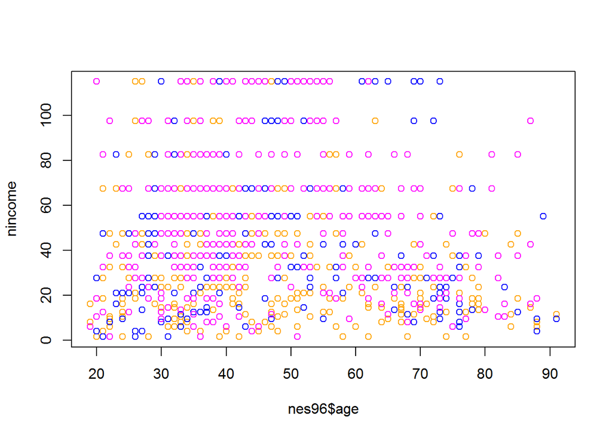

```r
idxD<-sPID=="Democrat"
idxI<-sPID=="Independent"
idxR<-sPID=="Republican"
plot(nes96$age,nincome)
points(nes96$age[idxD],nincome[idxD],col="orange")
points(nes96$age[idxI],nincome[idxI],col="blue")
points(nes96$age[idxR],nincome[idxR],col="magenta")
```

Points do not clearly separate.

Show how proportions of party affiliations change with education for the three party identifications.

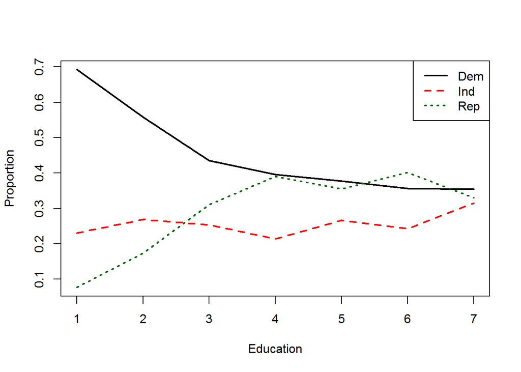

```r
matplot(prop.table(table(nes96$educ,sPID),1),type="l",xlab="Education",
        ylab="Proportion",lty=c(1,2,3),lwd=2,col=c("black","red","dark green"))
legend("topright",legend=c("Dem","Ind","Rep"),lty=c(1,2,3),col=c("black","red","dark green"),lwd=2)
```

Show changes of proportions with income level.

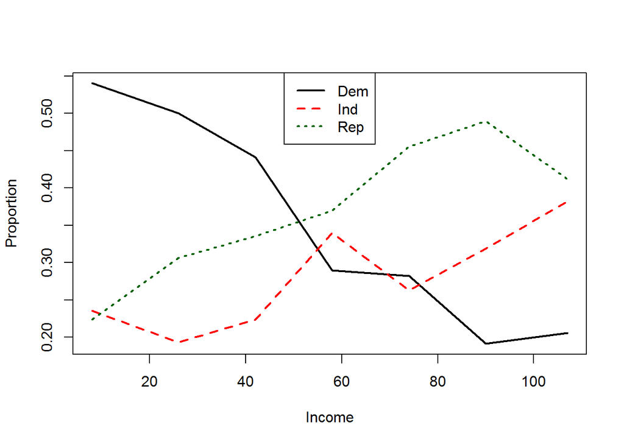

```r
cutinc<-cut(nincome,7)
il<-c(8,26,42,58,74,90,107)
matplot(il,prop.table(table(cutinc,sPID),1),type="l",xlab="Income",
        ylab="Proportion",lty=c(1,2,3),col=c("black","red","dark green"),lwd=2)
legend("top",legend=c("Dem","Ind","Rep"),lty=c(1,2,3),col=c("black","red","dark green"),lwd=2)
```

Show changes of proportions with age.

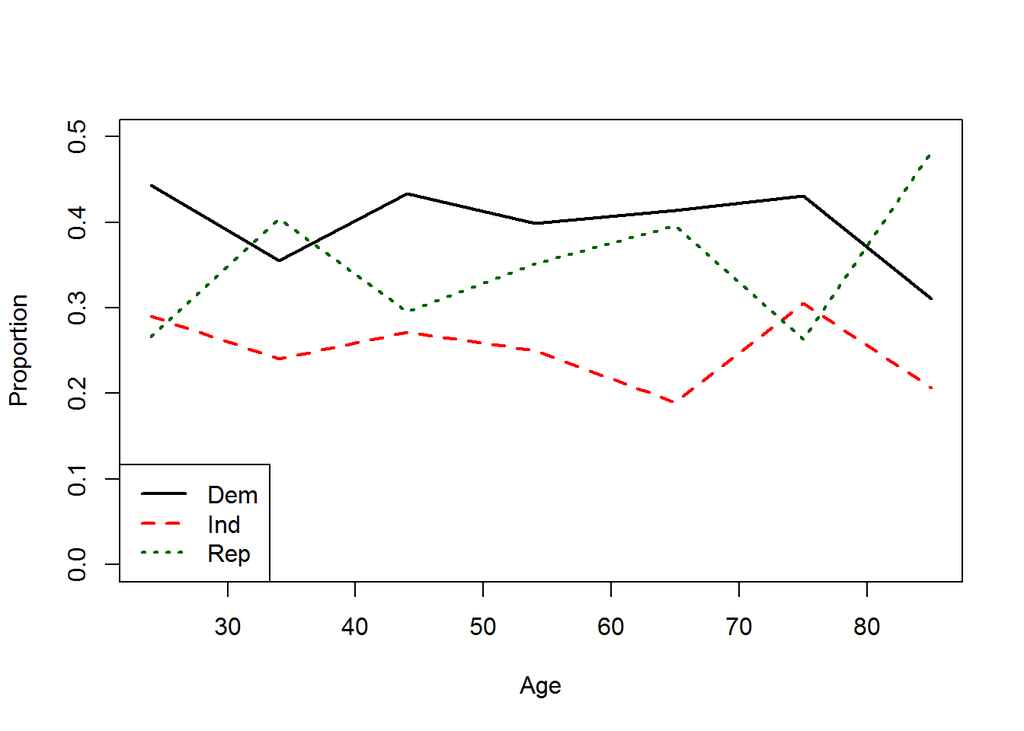

```r
cutage<-cut(nes96$age,7)
al<-c(24,34,44,54,65,75,85)
matplot(al,prop.table(table(cutage,sPID),1),type="l",xlab="Age",
        ylab="Proportion",lty=c(1,2,3),col=c("black","red","dark green"),ylim=c(0,.5),lwd=2)
legend("bottomleft",legend=c("Dem","Ind","Rep"),lty=c(1,2,3),col=c("black","red","dark green"),lwd=2)
```

Observe that:

- Affiliation with Democrats drops with education and levels at around college degree. At the same time affiliation with Republicans grows with education level and stabilizes around the same college degree level. Proportion of Independents remains pretty stable with educational level.
- Proportion of Democrats drops with income and Republicans show the opposite trend. Proportion of Independents also tends to grow, but slower than proportion of Republicans.
- Dependence of proportions on age is not strong for all three categories.

In order to assess statistical significance of these trends fit a multinomial logit model.

```r
mmod<-multinom(sPID~age+educ+nincome,data=nes96)
```

select variables for the model based on AIC using `step()`.

```r
mmodi<-step(mmod)
```

```
## Start:  AIC=2004.33
## sPID ~ age + educ + nincome
##
## trying - age
## trying - educ
## trying - nincome
##           Df      AIC
## - educ     6 1996.539
## - age     16 2003.625
## <none>    18 2004.333
## - nincome 16 2045.911
##
## Step:  AIC=1996.54
## sPID ~ age + nincome
##
## trying - age
## trying - nincome
##           Df      AIC
## - age      4 1993.424
## <none>     6 1996.539
## - nincome  4 2048.850
##
## Step:  AIC=1993.42
## sPID ~ nincome
##
## trying - nincome
##           Df      AIC
## <none>     4 1993.424
## - nincome  2 2045.272
```

```r
head(mmodi$fitted.values)
```

```
##    Democrat Independent Republican
## 1 0.5836466   0.1846557  0.2316977
## 2 0.5836466   0.1846557  0.2316977
## 3 0.5836466   0.1846557  0.2316977
## 4 0.5836466   0.1846557  0.2316977
## 5 0.5836466   0.1846557  0.2316977
## 6 0.5836466   0.1846557  0.2316977
```

```r
head(predict(mmodi,type="probs"))
```

```
##    Democrat Independent Republican
## 1 0.5836466   0.1846557  0.2316977
## 2 0.5836466   0.1846557  0.2316977
## 3 0.5836466   0.1846557  0.2316977
## 4 0.5836466   0.1846557  0.2316977
## 5 0.5836466   0.1846557  0.2316977
## 6 0.5836466   0.1846557  0.2316977
```

```r
head(predict(mmodi,type="class"))
```

```
## [1] Democrat Democrat Democrat Democrat Democrat Democrat
## Levels: Democrat Independent Republican
```

At the first step education gets removed, at the second step age is removed.  
The final model is `sPID~nincome`.

Plot probabilities of affiliations predicted by the model.

```r
(pred<-predict(mmodi,data.frame(nincome=il),type="probs"))
```

```
##    Democrat Independent Republican
## 1 0.5566253   0.1955183  0.2478565
## 2 0.4804946   0.2254595  0.2940459
## 3 0.4134268   0.2509351  0.3356381
## 4 0.3493884   0.2743178  0.3762939
## 5 0.2903271   0.2948600  0.4148129
## 6 0.2375755   0.3121136  0.4503109
## 7 0.1891684   0.3266848  0.4841468
```

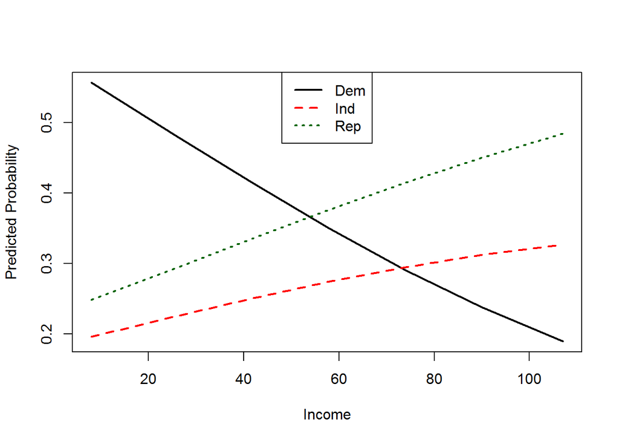

```r
matplot(il,pred,type="l",xlab="Income",ylab="Predicted Probability",
        lty=c(1,2,3),col=c("black","red","dark green"),lwd=2)
legend("top",legend=c("Dem","Ind","Rep"),lty=c(1,2,3),col=c("black","red","dark green"),lwd=2)
```

Interpret coefficients.

```r
summary(mmodi)
```

```
## Call:
## multinom(formula = sPID ~ nincome, data = nes96)
##
## Coefficients:
##             (Intercept)    nincome
## Independent  -1.1749331 0.01608683
## Republican   -0.9503591 0.01766457
##
## Std. Errors:
##             (Intercept)     nincome
## Independent   0.1536103 0.002849738
## Republican    0.1416859 0.002652532
##
## Residual Deviance: 1985.424
## AIC: 1993.424
```

```r
coef(mmodi)
```

```
##             (Intercept)    nincome
## Independent  -1.1749331 0.01608683
## Republican   -0.9503591 0.01766457
```

To predict probabilities at zero income level use intercepts:

```r
head(mmodi$fitted.values,1)
```

```
##    Democrat Independent Republican
## 1 0.5836466   0.1846557  0.2316977
```

```r
head(predict(mmodi,type="probs"),1)
```

```
##    Democrat Independent Republican
## 1 0.5836466   0.1846557  0.2316977
```

```r
exp(c(0,t(coef(mmodi))[1,]))/sum(exp(c(0,t(coef(mmodi))[1,])))
```

```
##             Independent  Republican
##   0.5898168   0.1821588   0.2280244
```

where `t(coef(mmodi))[1,]` equals row-vector of intercepts

```r
t(coef(mmodi))[1,]
```

```
## Independent  Republican
##  -1.1749331  -0.9503591
```

Compare with predicted probabilities at income level zero:

```r
predict(mmodi,data.frame(nincome=0),type="prob")
```

```
##    Democrat Independent  Republican
##   0.5898168   0.1821588   0.2280244
```

```r
exp(coef(mmodi)[1,1]) # exp of intercept Dem/Ind
```

```
## [1] 0.3088396
```

```r
predict(mmodi,data.frame(nincome=0),type="prob")[2]/   # P{Indep}/P{Dem}
  predict(mmodi,data.frame(nincome=0),type="prob")[1]
```

```
## Independent
##   0.3088396
```

```r
exp(coef(mmodi)[2,1]) # exp of intercept Dem/Rep
```

```
## [1] 0.3866022
```

```r
predict(mmodi,data.frame(nincome=0),type="prob")[3]/   # P{Rep}/P{Dem}
  predict(mmodi,data.frame(nincome=0),type="prob")[1]
```

```
## Republican
##  0.3866022
```

```r
coef(mmodi)[1,2] # slope Dem/Ind
```

```
## [1] 0.01608683
```

```r
odds.Ind_Dem.0<-log(predict(mmodi,data.frame(nincome=0),type="prob")[2]/   # P{Indep}/P{Dem}
  predict(mmodi,data.frame(nincome=0),type="prob")[1])
odds.Ind_Dem.1<-log(predict(mmodi,data.frame(nincome=1),type="prob")[2]/   # P{Indep}/P{Dem}
  predict(mmodi,data.frame(nincome=1),type="prob")[1])
odds.Ind_Dem.1-odds.Ind_Dem.0 # change of log odds Dem/Ind
```

```
## Independent
##  0.01608683
```

Another way to check this interpretation, first, predict probabilities with income difference of $1,000.

```r
(pred<-predict(mmodi,data.frame(nincome=c(0,1)),type="probs"))
```

```
##    Democrat Independent Republican
## 1 0.5898168   0.1821588  0.2280244
## 2 0.5857064   0.1838228  0.2304708
```

Then use these probabilities to calculate log odds.  
Log odds for multinomial model are defined as:

$$\eta_{i,j}=\beta_{0,j}+\beta_{1,j}x_{i,1}+\beta_{2,j}x_{i,2}+\ldots+\beta_{k,j}x_{i,k}=\ln \left( \frac{p_{i,j}}{p_{i,1}} \right),$$
where $p_{i,j}=P(Y_i=j), j=1,2,\ldots,J$.

```r
log(pred[1,1]*pred[2,2]/(pred[1,2]*pred[2,1]))
```

```
## [1] 0.01608683
```

Here log odds at income zero is by definition $\ln(\frac{p_{2,1}}{p_{1,1}})$ and log odds at income $1,000 is $\ln(\frac{p_{2,2}}{p_{1,2}})$.  
Then difference between them is

$$\ln \left( \frac{p_{2,2}}{p_{1,2}} \right)-\ln \left( \frac{p_{2,1}}{p_{1,1}} \right)=\ln \left( \frac{p_{2,2}}{p_{1,2}} \right)+\ln \left( \frac{p_{1,1}}{p_{2,1}} \right)=\ln \left( \frac{p_{2,2}}{p_{1,2}}\frac{p_{1,1}}{p_{2,1}} \right).$$

Similarly, calculate slope for Republican as log odds change:

```r
log(pred[1,1]*pred[2,3]/(pred[1,3]*pred[2,1]))
```

```
## [1] 0.01766457
```

```r
coef(mmodi)[2,2]
```

```
## [1] 0.01766457
```

## 2.2 Ordinal multinomial regression

Even though, categories of the response are not ordinal, fit proportional odds model using `polr()` from `MASS`.

```r
pomod<-polr(sPID~age+educ+nincome, data=nes96)
```

Compare deviance and number of parameters for `pomod` and `mmod`.

```r
rbind(Pomod=c(deviance=deviance(pomod),Parnum=pomod$edf),
      Mmod=c(deviance=deviance(mmod),Parnum=mmod$edf))
```

```
##       deviance Parnum
## Pomod 1984.211     10
## Mmod  1968.333     18
```

Proportional odds model has fewer parameters, but the fit is not as good as multinomial model has.  
Select variables using `step()`.

```r
pomodi<-step(pomod)
```

```
## Start:  AIC=2004.21
## sPID ~ age + educ + nincome
##
##           Df    AIC
## - educ     6 2002.8
## <none>       2004.2
## - age      1 2004.4
## - nincome  1 2038.6
##
## Step:  AIC=2002.83
## sPID ~ age + nincome
##
##           Df    AIC
## - age      1 2001.4
## <none>       2002.8
## - nincome  1 2047.2
##
## Step:  AIC=2001.36
## sPID ~ nincome
##
##           Df    AIC
## <none>       2001.4
## - nincome  1 2045.3
```

The result is the same as with multinomial regression: the resulting model is `sPID~nincome`.

# 3 Predicting the Medicare Functional Classification Level (K-level)

This example is based on paper [“How well can the Amputee Mobility Predictor and patient characteristics predict the Medicare Functional Classification Level (K-level) in people with unilateral transfemoral and transtibial amputation?”, Prosthetics & Orthotics International by M.P. Dillon, M.J. Major, B. Kaluf, Y. Balasanov and S. Fatone](http://journals.sagepub.com/doi/full/10.1177/0309364617706748).

When patients in the U.S. lose lower limbs due to amputation the amount of reimbursement paid by Medicare for prosthesis depends on assessment of medical necessity, including functional mobility and rehabilitation potential of individuals with lower limb loss. The amount of reimbursement in turn may affect the type of prosthesis obtained by amputee.  
For evaluation of functional mobility and rehabilitation potential [Centers for Medicare and Medicaid Services](https://www.cms.gov/) adopted the Medicare Functional Classification Level (MFCL) index called **K-levels**.  
K-levels is a five-level categorical index with categories from lowest level

- **Level 0**: “Does not have the ability or potential to ambulate or transfer safely with a prosthesis”

to highest level

- **Level 4**: “Patient has the ability or potential for prosthetic ambulation that exceeds the basic ambulation skills, exhibiting high impact, stress, or energy levels, typical of the prosthetic demands of the child, active adult, or athlete”.

Assignment of a K-level for each individual is made by a clinician based on qualitative description of each category. In order to avoid subjectivity in assignment process clinicians use the Amputee Mobility Predictor (AMP), a score system that is expected to predict K-level.  
In order to improve predictive power, AMP may be combined with additional objective predictors characterizing patients like age, weight, etc.  
Since K-levels response is an ordinal categorical variable prediction can be based on ordinal logistic regression.

In this workshop prediction of the Medicare Functional Classification Level (K-level) is done with only two out of several predictors used in the article: the Amputee Mobility Predictor (AMP) and amputee age.

Also for the purposes of this example we combine participants in the experiment with observed “K-level 1” and observed “K-level 2” in one category “K-level 2”.  
So, the response in these experimental data contains 3 levels: 2, 3 and 4.

Both predictors for this example were normalized.

```r
library(MASS)
library(nnet)
```

## 3.1 Data

Read the experiment data.

```r
dta<-read.csv(paste(dataPath,"Klevel_Prediction_Data.csv",sep="/"))
dta$K_level_F<-as.factor(dta$K_level)
```

Plot the data.

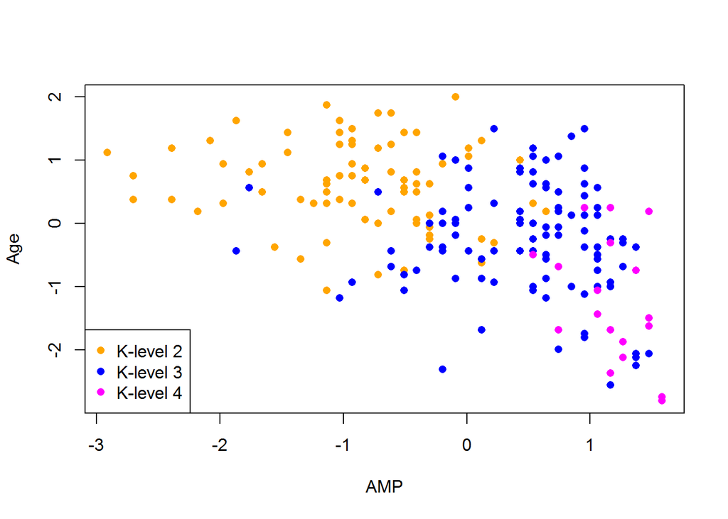

```r
idx2<-dta$K_level==2
idx3<-dta$K_level==3
idx4<-dta$K_level==4
plot(dta$AMP,dta$Age,col="orange",pch=16,xlab="AMP",ylab="Age")
points(dta$AMP[idx3],dta$Age[idx3],col="blue",pch=16)
points(dta$AMP[idx4],dta$Age[idx4],col="magenta",pch=16)
legend("bottomleft",
       legend=c("K-level 2","K-level 3","K-level 4"),
       pch=16,col=c("orange","blue","magenta"))
```

## 3.2 Fitting ordinal logistic regression

Use function `polr()` from library `MASS` to fit ordinal logistic regression model.

```r
orlog<-polr(K_level_F~AMP+Age,data=dta)
summary(orlog)
```

```
##
## Re-fitting to get Hessian
```

```
## Call:
## polr(formula = K_level_F ~ AMP + Age, data = dta)
##
## Coefficients:
##      Value Std. Error t value
## AMP  2.533     0.3518   7.199
## Age -1.031     0.2299  -4.487
##
## Intercepts:
##     Value   Std. Error t value
## 2|3 -0.8707  0.2362    -3.6867
## 3|4  4.7996  0.5255     9.1340
##
## Residual Deviance: 191.8599
## AIC: 199.8599
```

The summary shows that increase of normalized AMP score by 1 point changes odds for event “K-level $\le~j$” 0.0794492 times while increase of normalized age by 1 unit changes same odds 2.8048226 times.

Plot the data and the predicted K-level scores.

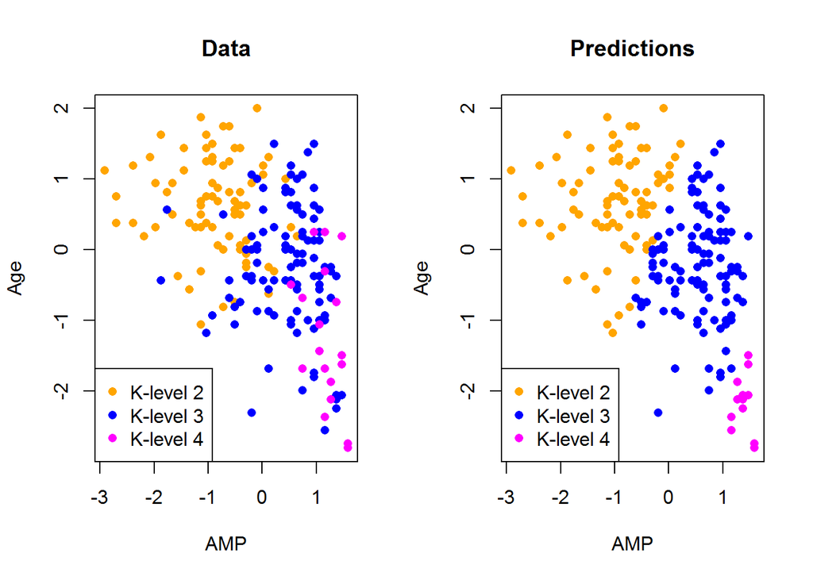

```r
orlogPred<-predict(orlog)
predIdx2<-orlogPred==2
predIdx3<-orlogPred==3
predIdx4<-orlogPred==4

par(mfrow=c(1,2))
plot(dta$AMP,dta$Age,col="orange",pch=16,xlab="AMP",ylab="Age",main="Data")
points(dta$AMP[idx3],dta$Age[idx3],col="blue",pch=16)
points(dta$AMP[idx4],dta$Age[idx4],col="magenta",pch=16)
legend("bottomleft",
       legend=c("K-level 2","K-level 3","K-level 4"),
       pch=16,col=c("orange","blue","magenta"))

plot(dta$AMP,dta$Age,col="orange",pch=16,xlab="AMP",ylab="Age",main="Predictions")
points(dta$AMP[predIdx3],dta$Age[predIdx3],col="blue",pch=16)
points(dta$AMP[predIdx4],dta$Age[predIdx4],col="magenta",pch=16)
legend("bottomleft",
       legend=c("K-level 2","K-level 3","K-level 4"),
       pch=16,col=c("orange","blue","magenta"))
```

```r
par(mfrow=c(1,1))
```

Plot on the left shows observed categories and plot on he right shows typical pattern of ordinal logistic regression with parallel hyperplanes separating the classes.

## 3.3 Fitting multinomial model

Fit multinomial model.

```r
mumod<-multinom(K_level_F~AMP+Age,data=dta)
summary(mumod)
```

```
## Call:
## multinom(formula = K_level_F ~ AMP + Age, data = dta)
##
## Coefficients:
##   (Intercept)      AMP       Age
## 3   0.9231895 2.513807 -1.350226
## 4  -4.0517687 5.713981 -1.867420
##
## Std. Errors:
##   (Intercept)       AMP       Age
## 3    0.258870 0.4055448 0.3302429
## 4    1.143145 1.1625700 0.4799671
##
## Residual Deviance: 188.5863
## AIC: 200.5863
```

```r
mumodPred<-predict(mumod)
```

Compare predictions by proportional odds model and multinomial model.

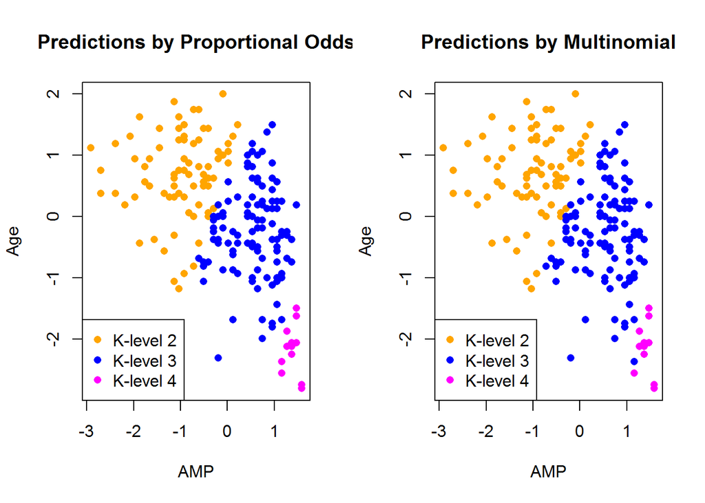

```r
mumodPredIdx2<-mumodPred==2
mumodPredIdx3<-mumodPred==3
mumodPredIdx4<-mumodPred==4

par(mfrow=c(1,2))
plot(dta$AMP,dta$Age,col="orange",pch=16,xlab="AMP",ylab="Age",
     main="Predictions by Proportional Odds")
points(dta$AMP[predIdx3],dta$Age[predIdx3],col="blue",pch=16)
points(dta$AMP[predIdx4],dta$Age[predIdx4],col="magenta",pch=16)
legend("bottomleft",
       legend=c("K-level 2","K-level 3","K-level 4"),
       pch=16,col=c("orange","blue","magenta"))


plot(dta$AMP,dta$Age,col="orange",pch=16,xlab="AMP",ylab="Age",main="Predictions by Multinomial")
points(dta$AMP[mumodPredIdx3],dta$Age[mumodPredIdx3],col="blue",pch=16)
points(dta$AMP[mumodPredIdx4],dta$Age[mumodPredIdx4],col="magenta",pch=16)
legend("bottomleft",
       legend=c("K-level 2","K-level 3","K-level 4"),
       pch=16,col=c("orange","blue","magenta"))
```

```r
par(mfrow=c(1,1))
```

Comparison shows that multinomial model is slightly more flexible and allows variation in slopes of hyperplanes separating different classes. For example, multinomial model estimates steeper slope between K-level 3 and K-level 4.

# 4 Using log loss function for model selection

For multi-class classification there is a common measure of quality of classification called log loss.

Let $N$ be the number of objects to classify, $M$ - number of classes, let also $y_{ij}$ be 1 if object $i$ belongs to class $j$, and 0 otherwise.  
Finally, let $p_{ij}$ be predicted probability that object $i$ belongs to class $j$.  
Vector $<p_{i1},p_{i2},.,p_{i,M}>$ is the output of the classification algorithm for object $i$.  
The formula for logloss is

$$logloss=-\frac{1}{N}\sum_{i=1}^{N}\sum_{j=1}^{M}y_{ij}\ln (p_{ij}).$$

For example, let the number of classes be $M=2$ and there is only one object that needs to be classified. Then the logloss formula is

$$logloss=-y_{11}\ln (p_{11})-y_{12}\ln (p_{12}).$$

If for this object the correct class is 1 then $y_{11}=1$, $y_{12}=0$ and $logloss= - \ln (p_{11})$.

In ideal case when the classification algorithm returned vector $<1,0>$. Then $logloss=0$.

If the algorithm classifies correctly, but assigns more uncertainty to the first class: $<0.7,0.3>$ then the penalty function is $logloss=-\ln (0.7)$ = 0.3566749.

If predicted probability for the first class is very small the penalty function can potentially go to infinity.  
That is why in practice very small input values $p_{ij}$ are replaced by $\max (\epsilon,p_{ij})$, where $\epsilon$ is a small positive number.  
For example, if $\epsilon=10^{-16}$ an incorrect forecast is a subject to worst penalty of 36.8413615.

For the same reason it is recommended to truncate values of probabilities too close to 1 by replacing $p_{ij} \ge 1-\epsilon$ with $1-\epsilon$.

Write function `MultiLogLoss <- function(act, pred)` for calculation of logloss using the formula above.

Argument `act` is a matrix $y_{ij},~i=1,\ldots,N;~j=1,\ldots,M,$ of actual classes. Each row $i$ should contain $M$ elements, all of them are zeros, except for position $m$ corresponding to the true class of observation $i$: $y_{im}=1$.

Argument `pred` is the matrix of prediction probabilities $p_{ij}$ of the same size as $y_{ij}$. Each row of this matrix is the vector of probabilities of observation $i$ belonging to class $j$.  
Second useful function is `response.matrix(Y)`, where the only argument is column of response, i.e. true class for each row. response column is formatted as factor.

This function returns matrix of $y_{ij},~i=1,\ldots,N;~j=1,\ldots,M$ necessary for log loss.

```r
MultiLogLoss <- function(act, pred)
{
  eps = 1e-15;
  if (!is.matrix(pred)) pred<-t(as.matrix(pred))
  if (!is.matrix(act)) act<-t(as.matrix(act))
  nr <- nrow(pred)
#  pred = matrix(sapply( pred, function(x) max(eps,x)), nrow = nr)
#  pred = matrix(sapply( pred, function(x) min(1-eps,x)), nrow = nr)
  #normalize rows
  ll = sum(act*log(sweep(pred, 1, rowSums(pred), FUN="/")))
  ll = -ll/nrow(act)
  return(ll);
}

response.matrix <- function(Y)
{
  y_res <- matrix(NA,nrow = 0,ncol = 3)
  for (i in 1:length(Y))
  {
    if (Y[i] == 2)
      y_res <- rbind(y_res,c(1,0,0))
    if (Y[i] == 3)
      y_res <- rbind(y_res,c(0,1,0))
    if (Y[i] == 4)
      y_res <- rbind(y_res,c(0,0,1))
  }
  return (y_res)
}
```

Use log loss function to decide which model fits the sample better.

Calculate the matrix of true responses and predicted probabilities of the K levels 2, 3, 4.

```r
trueY<-response.matrix(dta$K_level_F)
mumodProb<-predict(mumod, type="probs")
orlogProb<-predict(orlog, type="probs")
```

Replace small probabilities, less than $\epsilon=10^{-16}$, with $\epsilon$ and large probabilities, greater than $1-\epsilon=1-10^{-16}$ with $1-\epsilon$.  
Normalize probabilities in each row after truncating them.

```r
eps<-10^(-16)
nr <- nrow(mumodProb)
#truncate
mumodProb<-matrix(sapply(mumodProb, function(x) max(eps,x)), nrow = nr)
mumodProb<-matrix(sapply(mumodProb, function(x) min(1-eps,x)), nrow = nr)
orlogProb <- matrix(sapply(orlogProb, function(x) max(eps,x)), nrow = nr)
orlogProb <- matrix(sapply(orlogProb, function(x) min(1-eps,x)), nrow = nr)
#normalize rows
mumodProb<-sweep(mumodProb, 1, rowSums(mumodProb), FUN="/")
orlogProb<-sweep(orlogProb, 1, rowSums(orlogProb), FUN="/")
```

Call log loss function.

```r
MultiLogLoss(trueY,orlogProb)
```

```
## [1] 0.4844948
```

```r
MultiLogLoss(trueY,mumodProb)
```

```
## [1] 0.476228
```